This is a brief demonstration of common data manipulation and mapping techniques using spatial analysis tools in R. The goal here is to go from knowing nothing about shapefiles, to being able to create meaningful and attractive maps. For this exercise, I use crime data from Portland, Oregon that was provided by the National Institute of Justice for their [crime prediction competition](https://nij.gov/funding/Pages/fy16-crime-forecasting-challenge.aspx). The data and R scripts for this exercise are available at its [Github repository](https://github.com/hautahi/Rmaps).

### Loading Spatial Objects from Shape Files

Spatial data usually comes in the form of shapefiles, which can be loaded using the `readOGR` function from the `rgdal` package.

```r
library(rgdal)
port <- readOGR(dsn = "data", layer = "Police_Districts_Portland")
crime <- readOGR(dsn = "data", layer = "NIJ_Nov2016_Crime")
```

The `port` object contains information describing the geographic area of the 60 policing districts in Portland. The `crime` object contains data relating to every crime reported in Portland during the month of November 2016.

### Exploring Spatial Objects

If you’re used to regular R dataframes, you’ll find that spatial objects (represented by [S4 objects](http://adv-r.had.co.nz/S4.html)) are a little weird. But this allows a lot of flexibility. The first thing to know is that each spatial object belongs to one of many different “classes”. The most elementary type of spatial data are *Points*, which denote single point locations. *Lines* are a set of points connected by straight line segments that can be used to denote things like rivers or state boundaries. *Polygons* are shapes that denote area, and a *Grid* is a collection of cells organized into a regular grid. Running the `class()` command shows that the `port` object is a Spatial Polygons Data Frame and the `crime` object is a Spatial Points Data Frame. We can plot spatial objects easily using base R plot functions.

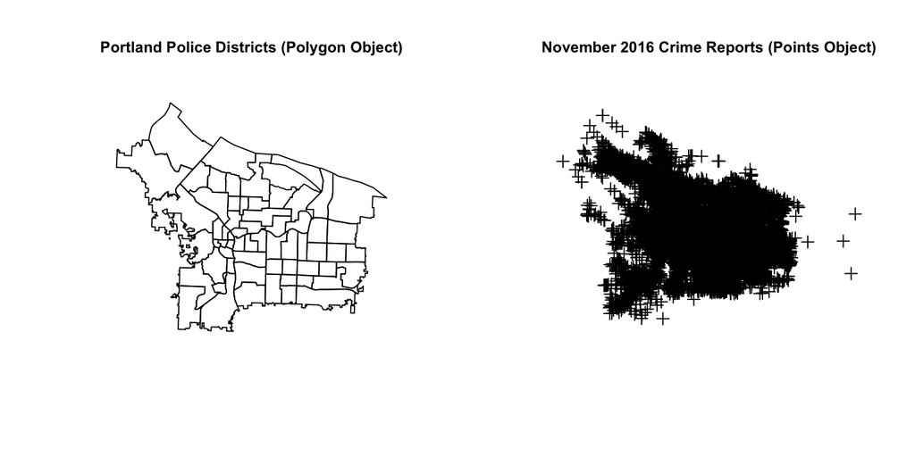

```r
par(mfrow=c(1,2))
plot(port); title(main = list("Portland Police Districts (Polygon Object)", cex=0.8))
plot(crime); title(main = list("November 2016 Crime Reports (Points Object)", cex=0.8))
```

The map on the left is made up of 60 *polygons*, each representing a policing district within Portland. The Polygon class is especially suited to describing regions or zones. The plot on the right shows a scattering of points that each describe the location of a particular crime reported in November 2016. The Points class is particularly suited to describing exact locations.

### Structure of Spatial Objects

The `summary()` command is a useful way of exploring a spatial object.

```r
summary(crime)
```

```
Object of class SpatialPointsDataFrame
Coordinates:
              min     max
coords.x1 7608809 7717689
coords.x2  651489  727287
Is projected: TRUE
proj4string :
[+proj=lcc +lat_1=44.33333333333334 +lat_2=46 +lat_0=43.66666666666666
+lon_0=-120.5 +x_0=2500000 +y_0=0 +ellps=GRS80 +units=ft +no_defs]
Number of points: 16834
Data attributes:
                CATEGORY           occ_date       census_tra
 BURGLARY           :   95   2016/11/04:  645   Min.   :     0
 MOTOR VEHICLE THEFT:  270   2016/11/03:  625   1st Qu.:  2000
 OTHER              :13889   2016/11/05:  607   Median :  4700
 STREET CRIMES      : 2580   2016/11/08:  607   Mean   :  6609
                             2016/11/06:  602   3rd Qu.:  8201
                             2016/11/01:  599   Max.   :980000
                             (Other)   :13149
```

The next few lines in the output above summarize the contents of the `Coordinates` slot, which holds the geographic coordinates of each crime. The displayed values are known as the “bounding box,” which gives the four points (or “corners”) that denote the spatial extent of the data. The spatial extent is basically the corners of the smallest rectangle that contains all the crime points. These values can be accessed with the `bbox()` command.

```r
bbox(crime)
```

```
              min     max
coords.x1 7608809 7717689
coords.x2  651489  727287
```

The next lines describe the projection characteristics of the `crime` object. A projection is an arbitrary coordinate reference system that provides a basis upon which to measure distances between objects in spatial data. All geographic objects are based on some form of coordinate system, and there are many different types of projections. The `proj4string` slot contains a string describing the projection information of the crime object’s coordinates. We’ll see below that some packages require us to change the projection system to one of the more common systems. The next line states that there were 16,834 recorded crime incidents in November 2016.

In addition to the geographic information, spatial objects also have additional data attributes that are contained in the `data` slot, which is actually a traditional R data frame. The output above shows that the `data` Data Frame has three columns - one describing the Category of each crime, one stating the date on which the crime occurred and one stating the census tract of each crime. Each row in the dataframe corresponds to a particular crime. The number of rows is therefore equal to the total number of crimes. Each slot can be accessed on its own via the `@` operator, as follows.

```r
head(crime@data)
```

```
       CATEGORY   occ_date census_tra
1 STREET CRIMES 2016/11/01       5200
2 STREET CRIMES 2016/11/01       7202
3 STREET CRIMES 2016/11/01      10600
4 STREET CRIMES 2016/11/01       1101
5 STREET CRIMES 2016/11/01       2000
6 STREET CRIMES 2016/11/01       1201
```

### Manipulating spatial data

It turns out that some of the crimes contained in `crime` occur outside the city of Portland defined by the `port` polygons. We can `clip` the crimes that occur outside the city using simple base R functions. Plotting the clipped and non-clipped data illustrates the point.

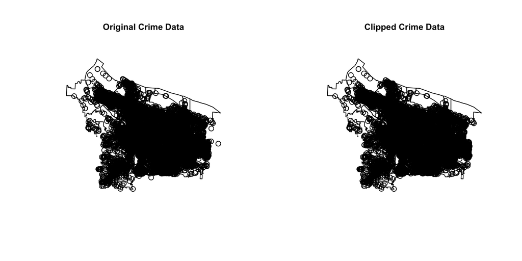

```r
crime_clp <- crime[port, ] # "Clip" crime to stay in same area

par(mfrow=c(1,2))
plot(port); points(crime); title(main = list("Original Crime Data", cex=0.8))
plot(port); points(crime_clp); title(main = list("Clipped Crime Data", cex=0.8))
```

When working with spatial data, we often want to make “cross polygon” comparisons. The `aggregate` function is very useful for this because it allows us to perform operations “by” polygons. The following code counts the number of crimes contained in `crime` by the polygons defined in `port`.

```r
crime_agg <- aggregate(x=crime["CATEGORY"],by=port,FUN=length) # Aggregate by district
summary(crime_agg)
```

```
Object of class SpatialPolygonsDataFrame
Coordinates:
        min       max
x 7604004.6 7701431.1
y  651315.6  733815.4
Is projected: TRUE
proj4string :
[+proj=lcc +lat_1=44.33333333333334 +lat_2=46 +lat_0=43.66666666666666
+lon_0=-120.5 +x_0=2500000 +y_0=0 +ellps=GRS80 +units=ft +no_defs]
Data attributes:
    CATEGORY
 Min.   :109.0
 1st Qu.:194.2
 Median :280.0
 Mean   :279.8
 3rd Qu.:345.8
 Max.   :512.0
```

The `aggregate` function identifies which `port` polygon (police district) each crime is committed in and groups them accordingly. Here we used the `CATEGORY` variable from the `crime@data` dataframe, although any variable could have been used here as we are merely counting how many points exist. The function then counts the number of crime points in each district, using the `length` function.

The `summary(crime_agg)` command shows that the new spatial object `crime_agg` is a polygon dataframe which has the same projection properties and “bounding box” as the `port` object. This is because the aggregate function simply counted the number of crimes whose x, y coordinates were in each of the polygons described by the `port` object. `crime_agg` only has one data attribute, however, which corresponds to the crime counts within each police district. Because there are only 60 police districts, we can actually just print the `CATEGORY` data column, which lists the crime count within each of the 60 districts. Each entry represents the number of crimes committed in the row corresponding to each polygon.

```r
print(crime_agg$CATEGORY)
```

```
 [1] 262 176 295 327 210 228 253 186 285 143 140 123 164 345 353 239 177 279 288 401 444
[22] 307 370 400 292 211 143 439 276 395 427 144 487 480 182 148 120 174 220 109 285 265
[43] 168 268 197 215 320 248 238 512 284 451 316 348 391 390 337 281 292 337
```

### Plotting spatial data with Leaflet

There are a number of very useful packages for plotting spatial data such as [ggmap](https://cran.r-project.org/web/packages/ggmap/index.html) and [tmap](https://cran.r-project.org/web/packages/tmap/index.html), which I will explore in a later post. Here, we will use Leaflet. It isn’t the simplest package, but it offers a lot of power, is apparently the [leading open-source](http://leafletjs.com/) mapping library and, in my opinion, looks cool. The first thing to do is to transform the projection of the coordinates, because some of the packages we will use require spatial data to be in a certain projection.

```r
crime_agg <- spTransform(crime_agg, CRS("+init=epsg:4326")) # Reproject coordinates
```

We’re going to create a choropleth map. The colorBin function of the Leaflet package divides the values into a specified number of bins (5 in this case) and maps these values to colors following a palette, in this case a palette of Reds. You can find information about the other palettes by typing `?RColorBrewer`.

```r
library(leaflet)
qpal <- colorBin("Reds", crime_agg$CATEGORY, bins=5)
```

Leaflet’s syntax is very similar to the popular ggplot syntax in the sense that you add layers to the map in steps. The first is to create a leaflet object from the `crime_agg` spatial object. We then use the `addPolygons` layer to overlay the police district outlines onto the map. We use the pallette mapping created above in the `fillColor` option. Finally, we add a legend.

```r
leaflet(crime_agg) %>%
  addPolygons(stroke = TRUE,opacity = 1,fillOpacity = 0.5, smoothFactor = 0.5,
              color="black",fillColor = ~qpal(CATEGORY),weight = 1) %>%
  addLegend(values=~CATEGORY,pal=qpal,title="Crime Count")
```

[interactive chart not shown]

### Creating a spatial grid

When working with spatial data, it’s often useful to work within our own evenly-spaced grid. The `raster` package is a simple way to make grids.

```r
library(raster)
e <- extent(bbox(port))                  # define boundaries of object
r <- raster(e)                           # create raster object
dim(r) <- c(40, 40)                      # specify number of cells
projection(r) <- CRS(proj4string(port))  # give it the same projection as port
g <- as(r, 'SpatialPolygonsDataFrame')   # convert into polygon
```

The first step in the code above is to define an `extent` object, which basically defines the “boundaries” of our raster grid. Here, I’ve used the boundaries of the `port` object accessed by the `bbox` command. The next line creates the raster object with our given extent. We then specify how many cells we’d like the raster to have. Here we specify the dimensions of the raster, which splits the extent into a 40 x 40 square grid. Finally, I give the raster cell the same projection orientation as `port`. The resulting `r` is a raster object, which we then convert into a spatial polygon object `g`. Inspecting `g`, we see that it has the same min and max x,y coordinates as `port` because we defined this in the extent above. There are no data attributes because we haven’t defined any.

```r
summary(g)
```

```
Object of class SpatialPolygonsDataFrame
Coordinates:
        min       max
x 7604004.6 7701431.1
y  651315.6  733815.4
Is projected: TRUE
proj4string :
[+proj=lcc +lat_1=44.33333333333334 +lat_2=46 +lat_0=43.66666666666666
+lon_0=-120.5 +x_0=2500000 +y_0=0 +ellps=GRS80 +units=ft +no_defs]
Data attributes:
     layer
 Min.   : NA
 1st Qu.: NA
 Median : NA
 Mean   :NaN
 3rd Qu.: NA
 Max.   : NA
 NA's   :1600
```

We now clip the new grid to match Portland and perform the same aggregation procedure to count the number of crimes within our newly defined (square) polygons.

```r
p <- g[port,]
crime_agg1 <- aggregate(x=crime["CATEGORY"],by=p,FUN=length)
```

Something to watch out for when using a fine grid, which are now a lot smaller than the initial police districts, is that some polygons may not have any crimes committed within them. The `length` function therefore takes the length of an empty vector in those cases, which returns a `NA` value. To avoid ugly `NA` parts on the map, we replace them with with zeros.

```r
crime_agg1$CATEGORY[is.na(crime_agg1$CATEGORY)] <- 0
```

Note that the above is simple base R code for dealing with dataframes. That’s because the object `crime_agg1$CATEGORY` is simply an R dataframe, which happens to live inside a spatial object.

```r
crime_agg1 <- spTransform(crime_agg1, CRS("+init=epsg:4326")) # reproject
qpal <- colorBin("Reds", crime_agg1$CATEGORY, bins=5)       # define color bins
leaflet(crime_agg1) %>%
  addPolygons(stroke = TRUE,opacity = 1,fillOpacity = 0.5, smoothFactor = 0.5,
              color="black",fillColor = ~qpal(CATEGORY),weight = 0.5) %>%
  addLegend(values=~CATEGORY,pal=qpal,title="Crime Count")
```

[interactive chart not shown]

The above looks pretty close, but because each of the grids are square, its only a rough approximation of the portland area. Ideally, we’d like our grid to exactly overlay the Portland map. This means trimming some of the outer squares. Using the `rgeos` package, we first “melt” the 60 Portland polygons into a single `portland` polygon. We then use the `gIntersection` function to find the polygon that is enclosed by both the `portland` polygons and the grid `p` we created above.

```r
library(rgeos)
 # Melt Portland districts into one polygon
portland = gUnaryUnion(port, port$dummy)
# Take the intersection of the grid and the Portland map
map <- gIntersection(p,portland,byid = TRUE,drop_lower_td = TRUE)
```

With this new polygon spatial object, we can then perform the same calculations.

```r
crime_agg2 <- aggregate(x=crime["CATEGORY"],by=map,FUN=length)
crime_agg2$CATEGORY[is.na(crime_agg2$CATEGORY)] <- 0
crime_agg2 <- spTransform(crime_agg2, CRS("+init=epsg:4326"))
qpal <- colorBin("Reds", crime_agg2$CATEGORY, bins=5)
plot3 <- leaflet(crime_agg2) %>%
  addPolygons(stroke = TRUE,opacity = 1,fillOpacity = 0.5, smoothFactor = 0.5,
              color="black",fillColor = ~qpal(CATEGORY),weight = 0.5) %>%
  addLegend(values=~CATEGORY,pal=qpal,title="Crime Count")
```

[interactive chart not shown]

Looking pretty good. Now we can add an open source version of a Portland map to see how our map looks on the actual city. We do this by appending the `addTiles()` function to our original plot

```r
plot4 <- plot3 %>% addTiles()
```

[interactive chart not shown]

Notice too that Leaflet plots are fully interactive. This means you can set the zoom using the `setView()` function as follows. We first find the center of portland using the `gCentroid` function, and then set the zoom. Default is 10, so this makes it slightly more zoomed in.

```r
cent <- gCentroid(crime_agg2) # Find center of map
plot5 <- plot4 %>% setView(zoom = 11,lng=cent@coords[[1]], lat=cent@coords[[2]])
```

[interactive chart not shown]

### Saving Shape Files

The `rgdal` package that we used to read in spatial data also has a useful `writeOGR` function for saving shapefiles.

```r
writeOGR(crime_agg2, dsn='output_data', layer='Portland', driver="ESRI Shapefile",
         overwrite_layer=T)
```

### References

There are a lot of great blog posts and textbooks out there. Some resources that I found particularly helpful were an [intro to spatial analysis in R](https://cran.r-project.org/doc/contrib/intro-spatial-rl.pdf) by Robin Lovelace and others, a [spatial data tutorial](https://pakillo.github.io/R-GIS-tutorial/) by Francisco Rodriguez-Sanchez, and a [set of tutorials](http://www.nickeubank.com/gis-in-r/) by Nick Eubank.